# Алгоритм Евклида

Мохаммад хоссейн фарзанфар

Российский Университет Дружбы Народов

4 , 2, 2025, Москва, Россия

# Цели и задачи

## Цель лабораторной работы

Изучение алгоритма Евклида нахождения НОД и его вариаций.

# Выполнение лабораторной работы

## Наибольший общий делитель

Наибольший общий делитель (НОД) – это число, которое делит без остатка два числа и делится само без остатка на любой другой делитель данных двух чисел. Проще говоря, это самое большое число, на которое можно без остатка разделить два числа, для которых ищется НОД.

## Алгоритм Евклида

- Вход. Целые числа *a*, *b*; 0 < *b* < *a*.
- Выход. *d*= НОД(*a*, *b*).
1. Положить *r*<sub>0</sub> = *a*, *r*<sub>1</sub> = *b*, *i* = 1.
2. Найти остаток *r*<sub>*i*</sub> + 1 от деления *r*<sub>*i*</sub>–1 на *r*<sub>*i*</sub>.
3. Если *r*<sub>*i*</sub> + 1 = 0, то положить *d* = *r*<sub>*i*</sub>. В противном случае положить *i* = *i* + 1 и вернуться на шаг 2.
4. Результат: *d*.

## Бинарный алгоритм Евклида

- Вход. Целые числа *a*, *b*; 0 < *b* ≤ *a*.
- Выход. *d*= HOД(*a*, *b*).
1. Положить *g* = 1.
2. Пока оба числа *a* и *b* четные, выполнять *a* = *a*/2, *b* = *b*/2, *g* = 2*g* до получения хотя бы одного нечетного значения *a* или *b*.
3. Положить *u* = *a*, *v* = *b*.
4. Пока *u* ≠ 0, выполнять следующие действия.
   - Пока *u* четное, полагать *u* = *u*/2.
   - Пока *v* четное, полагать *v* = *v*/2.
   - При *u* ≥ *v* положить *u* = *u* − *v*. В противном случае положить *v* = *v*–*u*.
5. Положить *d* = *g**v*.
6. Результат: *d*

## Расширенный алгоритм Евклида

- Вход. Целые числа *a*, *b*; 0 < *b* ≤ *a*.
- Выход: *d*= НОД(*a*, *b*); такие целые числа *x*, *y*, что *a**x* + *b**y* = *d*.
1. Положить *r*<sub>0</sub> = *a*, *r*<sub>1</sub> = *b*, *x*<sub>0</sub> = 1, *x*<sub>1</sub> = 0, *y*<sub>0</sub> = 0, *y*<sub>1</sub> = 1, *i* = 1
2. Разделить с остатком *r*<sub>*i*</sub>–1 на *r*<sub>*i*</sub> : *r*<sub>(*i*–1)</sub> = *q*<sub>*i*</sub> * *r*<sub>*i*</sub> + *r*<sub>*i*</sub> + 1
3. Если *r*<sub>(*i* + 1)</sub> = 0, то положить *d* = *r*<sub>*i*</sub>, *x* = *x*<sub>*i*</sub>, *y* = *y*<sub>*i*</sub>. В противном случае положить *x*<sub>(*i* + 1)</sub> = (*x*<sub>(*i*–1)</sub>–*q*<sub>*i*</sub> * *x*<sub>*i*</sub>, *y*<sub>(*i* + 1)</sub> = *y*<sub>(*i*–1)</sub>–*q*<sub>*i*</sub> * *y*<sub>*i*</sub>, *i* = *i* + 1 и вернуться на шаг 2.
4. Результат: *d*, *x*, *y*.

## Пример работы алгоритма

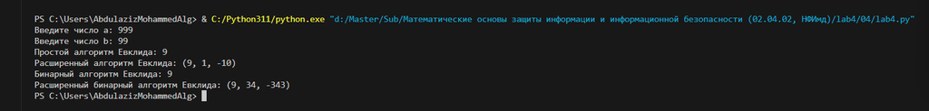

Работа алгоритма

# Выводы

## Результаты выполнения лабораторной работы

Изучили алгоритм Евклида нахождения НОД.